# Machine Learning

# Problem 1:

You are hired by one of the leading news channels CNBE who wants to analyze recent elections. This survey was conducted on 1525 voters with 9 variables. You have to build a model, to predict which party a voter will vote for on the basis of the given information, to create an exit poll that will help in predicting overall win and seats covered by a particular party.

### Data Dictionary:

**Variable Name**  
Vote  
Age  
Economic.cond.national  
Economic.cond.household  
Blair  
Hague  
Europe  
Political.knowledge  
Gender

## 1.1 Read the dataset. Do the descriptive statistics and do the null value condition check. Write an inference on it.

#### Upload Required Libraries

```python
# Pandas and Numpy libraries
import pandas as pd
import numpy as np
# For preprocessing the data
from sklearn import preprocessing
# To split the dataset into train and test datasets
from sklearn.model_selection import train_test_split
# To model the Gaussian Navie Bayes classifier
from sklearn.naive_bayes import GaussianNB
# To calculate the accuracy score of the model
from sklearn.metrics import accuracy_score
import seaborn as sns
import matplotlib.pyplot as plt
from scipy.stats import zscore
import warnings
warnings.filterwarnings( "ignore")
```

#### Importing data

```python
df=pd.read_csv('Election_Data.csv')
```

```python
df.head()
```

|  | vote | age | economic_cond_national | economic_cond_household | Blair | Hague | Europe | political_knowledge | gender |
| --- | --- | --- | --- | --- | --- | --- | --- | --- | --- |
| 0 | Labour | 43 | 3 | 3 | 4 | 1 | 2 | 2 | female |
| 1 | Labour | 36 | 4 | 4 | 4 | 4 | 5 | 2 | male |
| 2 | Labour | 35 | 4 | 4 | 5 | 2 | 3 | 2 | male |
| 3 | Labour | 24 | 4 | 2 | 2 | 1 | 4 | 0 | female |
| 4 | Labour | 41 | 2 | 2 | 1 | 1 | 6 | 2 | male |

#### As per the head of data, we can state that all are numerical value except vote and gender.

```python
df.shape
```

```
(1525, 9)
```

#### We have 1525 records with 9 variables in the dataset.

```python
df.info()
```

```
<class 'pandas.core.frame.DataFrame'>
RangeIndex: 1525 entries, 0 to 1524
Data columns (total 9 columns):
 #   Column                   Non-Null Count  Dtype
---  ------                   --------------  -----
 0   vote                     1525 non-null   object
 1   age                      1525 non-null   int64
 2   economic_cond_national   1525 non-null   int64
 3   economic_cond_household  1525 non-null   int64
 4   Blair                    1525 non-null   int64
 5   Hague                    1525 non-null   int64
 6   Europe                   1525 non-null   int64
 7   political_knowledge      1525 non-null   int64
 8   gender                   1525 non-null   object
dtypes: int64(7), object(2)
memory usage: 107.4+ KB
```

```python
df.describe(include = 'all').T
```

|  | count | unique | top | freq | mean | std | min | 25% | 50% | 75% | max |
| --- | --- | --- | --- | --- | --- | --- | --- | --- | --- | --- | --- |
| vote | 1525 | 2 | Labour | 1063 | NaN | NaN | NaN | NaN | NaN | NaN | NaN |
| age | 1525 | NaN | NaN | NaN | 54.1823 | 15.7112 | 24 | 41 | 53 | 67 | 93 |
| economic_cond_national | 1525 | NaN | NaN | NaN | 3.2459 | 0.880969 | 1 | 3 | 3 | 4 | 5 |
| economic_cond_household | 1525 | NaN | NaN | NaN | 3.14033 | 0.929951 | 1 | 3 | 3 | 4 | 5 |
| Blair | 1525 | NaN | NaN | NaN | 3.33443 | 1.17482 | 1 | 2 | 4 | 4 | 5 |
| Hague | 1525 | NaN | NaN | NaN | 2.74689 | 1.2307 | 1 | 2 | 2 | 4 | 5 |
| Europe | 1525 | NaN | NaN | NaN | 6.72852 | 3.29754 | 1 | 4 | 6 | 10 | 11 |
| political_knowledge | 1525 | NaN | NaN | NaN | 1.5423 | 1.08331 | 0 | 0 | 2 | 2 | 3 |
| gender | 1525 | 2 | female | 812 | NaN | NaN | NaN | NaN | NaN | NaN | NaN |

```python
dups = df.duplicated()
print('Number of duplicate rows = %d' % (dups.sum()))
df[dups]
```

```
Number of duplicate rows = 8
```

|  | vote | age | economic_cond_national | economic_cond_household | Blair | Hague | Europe | political_knowledge | gender |
| --- | --- | --- | --- | --- | --- | --- | --- | --- | --- |
| 67 | Labour | 35 | 4 | 4 | 5 | 2 | 3 | 2 | male |
| 626 | Labour | 39 | 3 | 4 | 4 | 2 | 5 | 2 | male |
| 870 | Labour | 38 | 2 | 4 | 2 | 2 | 4 | 3 | male |
| 983 | Conservative | 74 | 4 | 3 | 2 | 4 | 8 | 2 | female |
| 1154 | Conservative | 53 | 3 | 4 | 2 | 2 | 6 | 0 | female |
| 1236 | Labour | 36 | 3 | 3 | 2 | 2 | 6 | 2 | female |
| 1244 | Labour | 29 | 4 | 4 | 4 | 2 | 2 | 2 | female |
| 1438 | Labour | 40 | 4 | 3 | 4 | 2 | 2 | 2 | male |

```python
df.drop_duplicates(inplace=True)
```

```python
for column in df.columns:
    if df[column].dtype == 'object':
        print(column.upper(),': ',df[column].nunique())
        print(df[column].value_counts().sort_values())
        print('\n')
```

```
VOTE :  2
Conservative     460
Labour          1057
Name: vote, dtype: int64


GENDER :  2
male      709
female    808
Name: gender, dtype: int64
```

```python
df.isnull().sum()
```

```
vote                       0
age                        0
economic_cond_national     0
economic_cond_household    0
Blair                      0
Hague                      0
Europe                     0
political_knowledge        0
gender                     0
dtype: int64
```

```python
df.shape
```

```
(1517, 9)
```

#### Inference:

• There are 1517 rows without duplicate and 9 features, no null values present in the dataset  
• In dataset 7 are int variables and 2 are object variables  
• 8 duplicate rows are present in the dataset. We have removed the duplicates.

## 1.2 Perform Univariate and Bivariate Analysis. Do exploratory data analysis. Check for Outliers.

### Exploratory data analysis

```python
df.isnull().sum()
```

```
vote                       0
age                        0
economic_cond_national     0
economic_cond_household    0
Blair                      0
Hague                      0
Europe                     0
political_knowledge        0
gender                     0
dtype: int64
```

#### There is no null value present in the dataset.

```python
print(df.shape)
```

```
(1517, 9)
```

#### We have 1517 unique records with 9 variables in the dataset.

### Data Visualization

### Univariate Analysis

```python
df.describe()
```

|  | age | economic_cond_national | economic_cond_household | Blair | Hague | Europe | political_knowledge |
| --- | --- | --- | --- | --- | --- | --- | --- |
| count | 1517.000000 | 1517.000000 | 1517.000000 | 1517.000000 | 1517.000000 | 1517.000000 | 1517.000000 |
| mean | 54.241266 | 3.245221 | 3.137772 | 3.335531 | 2.749506 | 6.740277 | 1.540541 |
| std | 15.701741 | 0.881792 | 0.931069 | 1.174772 | 1.232479 | 3.299043 | 1.084417 |
| min | 24.000000 | 1.000000 | 1.000000 | 1.000000 | 1.000000 | 1.000000 | 0.000000 |
| 25% | 41.000000 | 3.000000 | 3.000000 | 2.000000 | 2.000000 | 4.000000 | 0.000000 |
| 50% | 53.000000 | 3.000000 | 3.000000 | 4.000000 | 2.000000 | 6.000000 | 2.000000 |
| 75% | 67.000000 | 4.000000 | 4.000000 | 4.000000 | 4.000000 | 10.000000 | 2.000000 |
| max | 93.000000 | 5.000000 | 5.000000 | 5.000000 | 5.000000 | 11.000000 | 3.000000 |

#### Insights:

• Voter age ranges from a minimum of 24 to maximum of 93  
• 75% of the voter are below or equal age of 67  
• As per other data description all are described with single digit. No need to scale the data.  
• In political knowledge, approximately 25% of the voters do not have political knowledge.

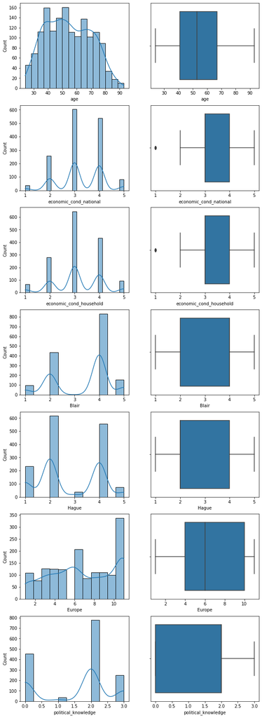

```python
fig, axes = plt.subplots(nrows=7,ncols=2)
fig.set_size_inches(10,30)
sns.histplot(df['age'], kde=True, ax=axes[0][0])
sns.boxplot(x='age', data=df, ax=axes[0][1])
sns.histplot(df['economic_cond_national'] , kde=True, ax=axes[1][0])
sns.boxplot(x='economic_cond_national', data=df , ax=axes[1][1])
sns.histplot(df['economic_cond_household'] , kde=True, ax=axes[2][0])
sns.boxplot(x='economic_cond_household', data=df , ax=axes[2][1])
sns.histplot(df['Blair'] , kde=True, ax=axes[3][0])
sns.boxplot(x='Blair', data=df , ax=axes[3][1])
sns.histplot(df['Hague'] , kde=True, ax=axes[4][0])
sns.boxplot(x='Hague', data=df , ax=axes[4][1])
sns.histplot(df['Europe'] , kde=True, ax=axes[5][0])
sns.boxplot(x='Europe', data=df , ax=axes[5][1])
sns.histplot(df['political_knowledge'] , kde=True, ax=axes[6][0])
sns.boxplot(x='political_knowledge', data=df , ax=axes[6][1])
plt.show()
```

#### Insights:

All fields not have outliers except few outliers in economic_cond_national and economic_cond_household. Age only normally distributed, others are have different data pattern waves.

### Categorical Variable

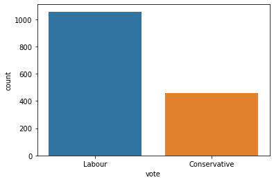

```python
sns.countplot(x='vote', data=df)
```

#### Insights:

Labours are maximum voters in dataset.

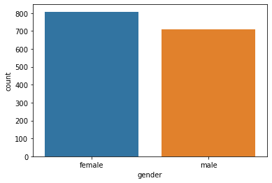

```python
sns.countplot(x='gender', data=df)
```

#### Insights:

Females are maximum voters in dataset.

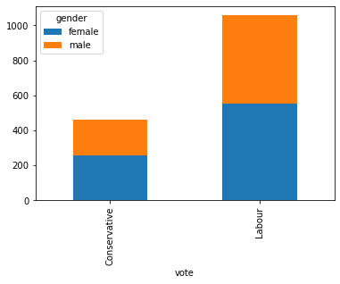

```python
pd.crosstab(df['vote'], df['gender']).plot(kind = 'bar', stacked = True)
```

#### Insights:

Females are maximum voters in both Labour and Conservative dataset.

### Bivariate Analysis

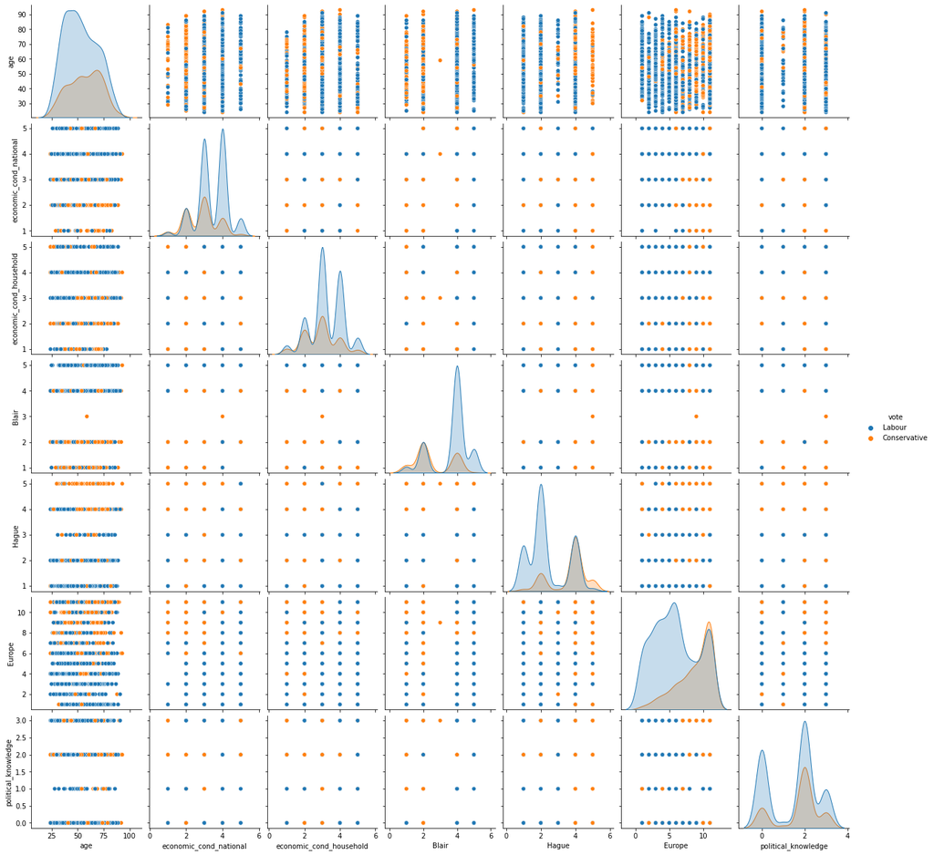

```python
sns.pairplot(df, hue='vote')
plt.show()
```

**Inference:**  
As per scatter plot in Bivariate analysis, Age with each other variables only have strong pattern and others variable with each other scatter with more distances.

### Multivariate Analysis

```python
df.corr()
```

|  | age | economic_cond_national | economic_cond_household | Blair | Hague | Europe | political_knowledge |
| --- | --- | --- | --- | --- | --- | --- | --- |
| age | 1.000000 | 0.018687 | -0.038868 | 0.032084 | 0.031144 | 0.064562 | -0.046598 |
| economic_cond_national | 0.018687 | 1.000000 | 0.347687 | 0.326141 | -0.200790 | -0.209150 | -0.023510 |
| economic_cond_household | -0.038868 | 0.347687 | 1.000000 | 0.215822 | -0.100392 | -0.112897 | -0.038528 |
| Blair | 0.032084 | 0.326141 | 0.215822 | 1.000000 | -0.243508 | -0.295944 | -0.021299 |
| Hague | 0.031144 | -0.200790 | -0.100392 | -0.243508 | 1.000000 | 0.285738 | -0.029906 |
| Europe | 0.064562 | -0.209150 | -0.112897 | -0.295944 | 0.285738 | 1.000000 | -0.151197 |
| political_knowledge | -0.046598 | -0.023510 | -0.038528 | -0.021299 | -0.029906 | -0.151197 | 1.000000 |

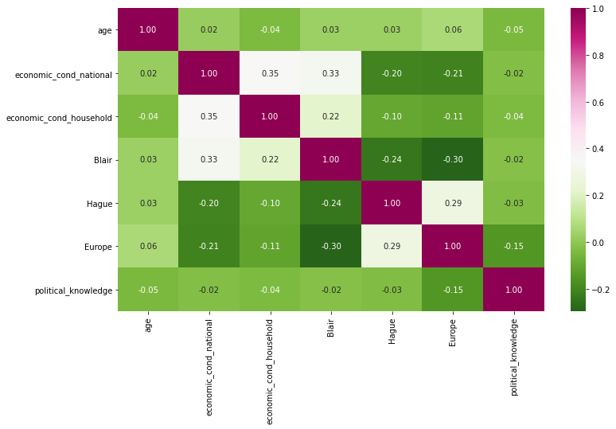

```python
plt.figure(figsize=(12,7))
sns.heatmap(df.corr(), annot=True, fmt='.2f', cmap= 'PiYG_r')
plt.show()
```

#### Inference: As per the heat map, multi collinearity not present in the dataset.

### Check for outliers

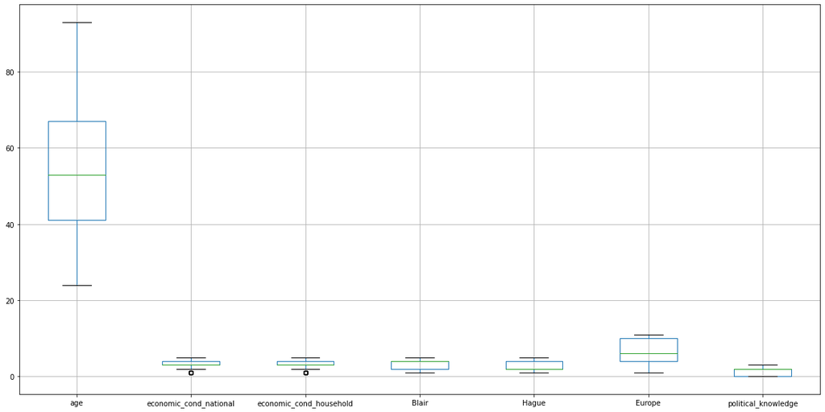

```python
plt.figure(figsize=(20,10))
df.boxplot()
plt.show()
```

#### economic_cond_national and economic_cond_household slightly have outliers. No need to treat outliers since that is not going to after the data.

## 1.3 Encode the data (having string values) for Modelling. Is Scaling necessary here or not? Data Split: Split the data into train and test (70:30).

```python
from sklearn.preprocessing import StandardScaler
std_scale = StandardScaler()
std_scale
```

```
StandardScaler()
```

```python
df_scale=df.copy()
```

```python
df_scale['age'] = std_scale.fit_transform(df_scale[['age']])
df_scale['economic_cond_national'] = std_scale.fit_transform(df_scale[['economic_cond_national']])
df_scale['economic_cond_household'] = std_scale.fit_transform(df_scale[['economic_cond_household']])
df_scale['Blair'] = std_scale.fit_transform(df_scale[['Blair']])
df_scale['Hague'] = std_scale.fit_transform(df_scale[['Hague']])
df_scale['Europe'] = std_scale.fit_transform(df_scale[['Europe']])
df_scale['political_knowledge'] = std_scale.fit_transform(df_scale[['political_knowledge']])
```

```python
df_scale.head()
```

|  | vote | age | economic_cond_national | economic_cond_household | Blair | Hague | Europe | political_knowledge | gender |
| --- | --- | --- | --- | --- | --- | --- | --- | --- | --- |
| 0 | Labour | -0.716161 | -0.278185 | -0.148020 | 0.565802 | -1.419969 | -1.437338 | 0.423832 | female |
| 1 | Labour | -1.162118 | 0.856242 | 0.926367 | 0.565802 | 1.014951 | -0.527684 | 0.423832 | male |
| 2 | Labour | -1.225827 | 0.856242 | 0.926367 | 1.417312 | -0.608329 | -1.134120 | 0.423832 | male |
| 3 | Labour | -1.926617 | 0.856242 | -1.222408 | -1.137217 | -1.419969 | -0.830902 | -1.421084 | female |
| 4 | Labour | -0.843577 | -1.412613 | -1.222408 | -1.988727 | -1.419969 | -0.224465 | 0.423832 | male |

```python
df_scale.describe().iloc[1:3,:]
```

|  | age | economic_cond_national | economic_cond_household | Blair | Hague | Europe | political_knowledge |
| --- | --- | --- | --- | --- | --- | --- | --- |
| mean | 1.917458e-17 | -1.984789e-16 | -2.397189e-16 | -1.034842e-16 | 5.386448e-17 | 6.293947e-17 | -7.665442e-16 |
| std | 1.000330e+00 | 1.000330e+00 | 1.000330e+00 | 1.000330e+00 | 1.000330e+00 | 1.000330e+00 | 1.000330e+00 |

```python
df.describe().iloc[1:3,:]
```

|  | age | economic_cond_national | economic_cond_household | Blair | Hague | Europe | political_knowledge |
| --- | --- | --- | --- | --- | --- | --- | --- |
| mean | 54.241266 | 3.245221 | 3.137772 | 3.335531 | 2.749506 | 6.740277 | 1.540541 |
| std | 15.701741 | 0.881792 | 0.931069 | 1.174772 | 1.232479 | 3.299043 | 1.084417 |

From comparison of mean and standard deviation of both scaled and unscaled data, we can get std for all features are same and get very small or negative mean values in scaled data. However we get positive mean values and unique std for all features in unscaled data.

As per the original dataset all are in same unit of measure. So, no need to scale the data for modelling

### Data encoding

```python
cat = ['vote', 'gender']
df =pd.get_dummies(df, columns=cat, drop_first=True)
```

```python
df.head()
```

|  | age | economic_cond_national | economic_cond_household | Blair | Hague | Europe | political_knowledge | vote_Labour | gender_male |
| --- | --- | --- | --- | --- | --- | --- | --- | --- | --- |
| 0 | 43 | 3 | 3 | 4 | 1 | 2 | 2 | 1 | 0 |
| 1 | 36 | 4 | 4 | 4 | 4 | 5 | 2 | 1 | 1 |
| 2 | 35 | 4 | 4 | 5 | 2 | 3 | 2 | 1 | 1 |
| 3 | 24 | 4 | 2 | 2 | 1 | 4 | 0 | 1 | 0 |
| 4 | 41 | 2 | 2 | 1 | 1 | 6 | 2 | 1 | 1 |

#### Scaling

#### No, Scaling is not necessary. Since, in the given dataset all variables have same units of measure with respect to other.

## Train/ Test split for the data

#### Extracting the target column into separate vectors for training set and test set

```python
x = df.drop('vote_Labour', axis=1)
y = df[['vote_Labour']]
```

#### Splitting data into training and test set

```python
x_train, x_test, y_train, y_test = train_test_split(x, y, test_size=.30, random_state=1)
```

There is a specific to choose partion ratio as 70:30. Total observation in our dataset is 1517.

Train and Test dataset for both Independant and Dependant variable are given below.

```python
pd.DataFrame(x_train)
```

|  | age | economic_cond_national | economic_cond_household | Blair | Hague | Europe | political_knowledge | gender_male |
| --- | --- | --- | --- | --- | --- | --- | --- | --- |
| 991 | 34 | 2 | 4 | 1 | 4 | 11 | 2 | 0 |
| 1274 | 40 | 4 | 3 | 4 | 4 | 6 | 0 | 1 |
| 649 | 61 | 4 | 3 | 4 | 4 | 7 | 2 | 0 |
| 677 | 47 | 3 | 3 | 4 | 2 | 11 | 0 | 1 |
| 538 | 44 | 5 | 3 | 4 | 2 | 8 | 0 | 1 |
| ... | ... | ... | ... | ... | ... | ... | ... | ... |
| 717 | 52 | 3 | 3 | 4 | 1 | 6 | 2 | 0 |
| 908 | 43 | 3 | 4 | 2 | 2 | 9 | 2 | 0 |
| 1100 | 74 | 4 | 3 | 5 | 4 | 11 | 0 | 0 |
| 236 | 31 | 3 | 3 | 2 | 3 | 6 | 0 | 0 |
| 1065 | 89 | 3 | 5 | 4 | 2 | 1 | 0 | 1 |

1061 rows × 8 columns

```python
pd.DataFrame(x_test)
```

|  | age | economic_cond_national | economic_cond_household | Blair | Hague | Europe | political_knowledge | gender_male |
| --- | --- | --- | --- | --- | --- | --- | --- | --- |
| 504 | 71 | 3 | 3 | 2 | 2 | 8 | 2 | 0 |
| 369 | 43 | 3 | 2 | 4 | 2 | 8 | 3 | 1 |
| 1075 | 89 | 5 | 5 | 5 | 2 | 1 | 2 | 1 |
| 1031 | 47 | 2 | 3 | 2 | 4 | 8 | 2 | 0 |
| 1329 | 33 | 5 | 4 | 4 | 4 | 8 | 0 | 1 |
| ... | ... | ... | ... | ... | ... | ... | ... | ... |
| 562 | 37 | 4 | 2 | 4 | 2 | 8 | 1 | 1 |
| 928 | 42 | 2 | 2 | 1 | 2 | 7 | 2 | 0 |
| 276 | 88 | 3 | 3 | 4 | 1 | 6 | 0 | 0 |
| 1128 | 53 | 4 | 3 | 4 | 2 | 10 | 0 | 0 |
| 1151 | 36 | 3 | 3 | 4 | 1 | 6 | 3 | 1 |

456 rows × 8 columns

```python
pd.DataFrame(y_train)
```

|  | vote_Labour |
| --- | --- |
| 991 | 0 |
| 1274 | 1 |
| 649 | 0 |
| 677 | 1 |
| 538 | 1 |
| ... | ... |
| 717 | 1 |
| 908 | 0 |
| 1100 | 1 |
| 236 | 1 |
| 1065 | 1 |

1061 rows × 1 columns

```python
pd.DataFrame(y_test)
```

|  | vote_Labour |
| --- | --- |
| 504 | 1 |
| 369 | 1 |
| 1075 | 1 |
| 1031 | 0 |
| 1329 | 1 |
| ... | ... |
| 562 | 1 |
| 928 | 1 |
| 276 | 1 |
| 1128 | 1 |
| 1151 | 1 |

456 rows × 1 columns

#### Checking the dimensions of the training and test data

```python
print('x_train',x_train.shape)
print('x_test',x_test.shape)
print('y_train',y_train.shape)
print('y_test',y_test.shape)
```

```
x_train (1061, 8)
x_test (456, 8)
y_train (1061, 1)
y_test (456, 1)
```

Here are the data split dimensions defined for the ratio of 70:30.

## 1.4 Apply Logistic Regression and LDA (linear discriminant analysis).

### Logistic Regression Model

```python
from sklearn.model_selection import train_test_split
from sklearn.linear_model import LogisticRegression
from sklearn import metrics
import scipy.stats as stats
from sklearn.model_selection import train_test_split,GridSearchCV
from sklearn.metrics import roc_auc_score,roc_curve,classification_report,confusion_matrix,plot_confusion_matrix
```

```python
# Fit the Logistic Regression model
grid={'penalty':['l2','none'],
      'solver':['sag','lbfgs','newton-cg'],
      'tol':[0.0001,0.00001]}
```

```python
model = LogisticRegression(max_iter=10000,verbose=True,n_jobs=2)
```

```python
grid_search = GridSearchCV(estimator = model, param_grid = grid, cv = 3,n_jobs=-1,scoring='f1')
```

```python
grid_search.fit(x_train, y_train)
```

```
[Parallel(n_jobs=2)]: Using backend ThreadingBackend with 2 concurrent workers.
```

```
convergence after 2525 epochs took 1 seconds
```

```
[Parallel(n_jobs=2)]: Done   1 out of   1 | elapsed:    0.8s finished
```

```
GridSearchCV(cv=3,
             estimator=LogisticRegression(max_iter=10000, n_jobs=2,
                                          verbose=True),
             n_jobs=-1,
             param_grid={'penalty': ['l2', 'none'],
                         'solver': ['sag', 'lbfgs', 'newton-cg'],
                         'tol': [0.0001, 1e-05]},
             scoring='f1')
```

```python
print(grid_search.best_params_,'\n')
print(grid_search.best_estimator_)
```

```
{'penalty': 'l2', 'solver': 'sag', 'tol': 1e-05}

LogisticRegression(max_iter=10000, n_jobs=2, solver='sag', tol=1e-05,
                   verbose=True)
```

```python
best_model = grid_search.best_estimator_
```

#### Predicting on Training and Test dataset

```python
ytrain_predict = best_model.predict(x_train)
ytest_predict = best_model.predict(x_test)
```

#### Getting the Predicted Classes and Probs

```python
ytest_predict_prob=best_model.predict_proba(x_test)
pd.DataFrame(ytest_predict_prob).head()
```

|  | 0 | 1 |
| --- | --- | --- |
| 0 | 0.424473 | 0.575527 |
| 1 | 0.151097 | 0.848903 |
| 2 | 0.007167 | 0.992833 |
| 3 | 0.834981 | 0.165019 |
| 4 | 0.069242 | 0.930758 |

### Logistic Regression Model Evaluation

```python
# Accuracy - Training Data
lr_train_acc = best_model.score(x_train, y_train)
lr_train_acc
```

```
0.8322337417530632
```

```python
# Accuracy - Test Data
lr_test_acc = best_model.score(x_test, y_test)
lr_test_acc
```

```
0.8267543859649122
```

#### AUC and ROC for the training data

```
AUC: 0.890
```

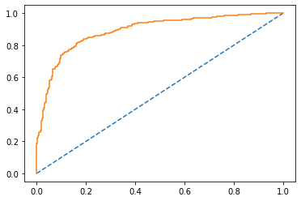

```python
# predict probabilities
probs = best_model.predict_proba(x_train)
# keep probabilities for the positive outcome only
probs = probs[:, 1]
# calculate AUC
lr_train_auc = roc_auc_score(y_train, probs)
print('AUC: %.3f' % lr_train_auc)
# calculate roc curve
train_fpr, train_tpr, train_thresholds = roc_curve(y_train, probs)
plt.plot([0, 1], [0, 1], linestyle='--')
# plot the roc curve for the model
plt.plot(train_fpr, train_tpr);
```

#### AUC and ROC for the test data

```
AUC: 0.882
```

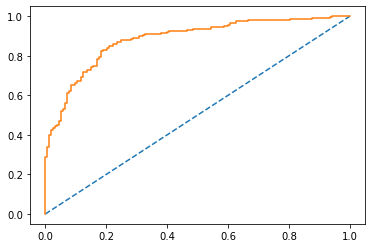

```python
# predict probabilities
probs = best_model.predict_proba(x_test)
# keep probabilities for the positive outcome only
probs = probs[:, 1]
# calculate AUC
lr_test_auc = roc_auc_score(y_test, probs)
print('AUC: %.3f' % lr_test_auc)
# calculate roc curve
test_fpr, test_tpr, test_thresholds = roc_curve(y_test, probs)
plt.plot([0, 1], [0, 1], linestyle='--')
# plot the roc curve for the model
plt.plot(test_fpr, test_tpr);
```

#### Confusion Matrix for the training data

```python
confusion_matrix(y_train, ytrain_predict)
```

```
array([[196, 111],
       [ 67, 687]], dtype=int64)
```

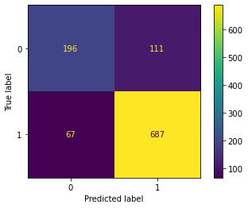

```python
plot_confusion_matrix(best_model,x_train,y_train);
```

```python
print(classification_report(y_train, ytrain_predict))
```

```
              precision    recall  f1-score   support

           0       0.75      0.64      0.69       307
           1       0.86      0.91      0.89       754

    accuracy                           0.83      1061
   macro avg       0.80      0.77      0.79      1061
weighted avg       0.83      0.83      0.83      1061
```

```python
lr_metrics=classification_report(y_train, ytrain_predict,output_dict=True)
df5=pd.DataFrame(lr_metrics).transpose()
lr_train_f1=round(df5.loc["1"][2],2)
lr_train_recall=round(df5.loc["1"][1],2)
lr_train_precision=round(df5.loc["1"][0],2)
print ('lr_train_precision ',lr_train_precision)
print ('lr_train_recall ',lr_train_recall)
print ('lr_train_f1 ',lr_train_f1)
```

```
lr_train_precision  0.86
lr_train_recall  0.91
lr_train_f1  0.89
```

#### Confusion Matrix for test data

```python
confusion_matrix(y_test, ytest_predict)
```

```
array([[110,  43],
       [ 36, 267]], dtype=int64)
```

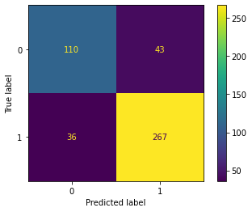

```python
plot_confusion_matrix(best_model,x_test,y_test);
```

```python
print(classification_report(y_test, ytest_predict))
```

```
              precision    recall  f1-score   support

           0       0.75      0.72      0.74       153
           1       0.86      0.88      0.87       303

    accuracy                           0.83       456
   macro avg       0.81      0.80      0.80       456
weighted avg       0.83      0.83      0.83       456
```

```python
lr_metrics=classification_report(y_test, ytest_predict,output_dict=True)
df5=pd.DataFrame(lr_metrics).transpose()
lr_test_f1=round(df5.loc["1"][2],2)
lr_test_recall=round(df5.loc["1"][1],2)
lr_test_precision=round(df5.loc["1"][0],2)
print ('lr_test_precision ',lr_test_precision)
print ('lr_test_recall ',lr_test_recall)
print ('lr_test_f1 ',lr_test_f1)
```

```
lr_test_precision  0.86
lr_test_recall  0.88
lr_test_f1  0.87
```

### Linear Discriminant Analysis (LDA)

#### Build LDA Model

```python
from sklearn.discriminant_analysis import LinearDiscriminantAnalysis
```

### Train/ Test split

#### Extracting the target column into separate vectors for training set and test set

```python
X = df.drop('vote_Labour', axis=1)
Y = df[['vote_Labour']]
```

#### Splitting data into training and test set

```python
X_train, X_test, Y_train, Y_test = train_test_split(X, Y, test_size=.30, random_state=1)
```

Train and Test dataset for both Independant and Dependant variable are given below.

```python
pd.DataFrame(X_train)
```

|  | age | economic_cond_national | economic_cond_household | Blair | Hague | Europe | political_knowledge | gender_male |
| --- | --- | --- | --- | --- | --- | --- | --- | --- |
| 991 | 34 | 2 | 4 | 1 | 4 | 11 | 2 | 0 |
| 1274 | 40 | 4 | 3 | 4 | 4 | 6 | 0 | 1 |
| 649 | 61 | 4 | 3 | 4 | 4 | 7 | 2 | 0 |
| 677 | 47 | 3 | 3 | 4 | 2 | 11 | 0 | 1 |
| 538 | 44 | 5 | 3 | 4 | 2 | 8 | 0 | 1 |
| ... | ... | ... | ... | ... | ... | ... | ... | ... |
| 717 | 52 | 3 | 3 | 4 | 1 | 6 | 2 | 0 |
| 908 | 43 | 3 | 4 | 2 | 2 | 9 | 2 | 0 |
| 1100 | 74 | 4 | 3 | 5 | 4 | 11 | 0 | 0 |
| 236 | 31 | 3 | 3 | 2 | 3 | 6 | 0 | 0 |
| 1065 | 89 | 3 | 5 | 4 | 2 | 1 | 0 | 1 |

1061 rows × 8 columns

```python
pd.DataFrame(X_test)
```

|  | age | economic_cond_national | economic_cond_household | Blair | Hague | Europe | political_knowledge | gender_male |
| --- | --- | --- | --- | --- | --- | --- | --- | --- |
| 504 | 71 | 3 | 3 | 2 | 2 | 8 | 2 | 0 |
| 369 | 43 | 3 | 2 | 4 | 2 | 8 | 3 | 1 |
| 1075 | 89 | 5 | 5 | 5 | 2 | 1 | 2 | 1 |
| 1031 | 47 | 2 | 3 | 2 | 4 | 8 | 2 | 0 |
| 1329 | 33 | 5 | 4 | 4 | 4 | 8 | 0 | 1 |
| ... | ... | ... | ... | ... | ... | ... | ... | ... |
| 562 | 37 | 4 | 2 | 4 | 2 | 8 | 1 | 1 |
| 928 | 42 | 2 | 2 | 1 | 2 | 7 | 2 | 0 |
| 276 | 88 | 3 | 3 | 4 | 1 | 6 | 0 | 0 |
| 1128 | 53 | 4 | 3 | 4 | 2 | 10 | 0 | 0 |
| 1151 | 36 | 3 | 3 | 4 | 1 | 6 | 3 | 1 |

456 rows × 8 columns

```python
pd.DataFrame(Y_train)
```

|  | vote_Labour |
| --- | --- |
| 991 | 0 |
| 1274 | 1 |
| 649 | 0 |
| 677 | 1 |
| 538 | 1 |
| ... | ... |
| 717 | 1 |
| 908 | 0 |
| 1100 | 1 |
| 236 | 1 |
| 1065 | 1 |

1061 rows × 1 columns

```python
pd.DataFrame(Y_test)
```

|  | vote_Labour |
| --- | --- |
| 504 | 1 |
| 369 | 1 |
| 1075 | 1 |
| 1031 | 0 |
| 1329 | 1 |
| ... | ... |
| 562 | 1 |
| 928 | 1 |
| 276 | 1 |
| 1128 | 1 |
| 1151 | 1 |

456 rows × 1 columns

#### Checking the dimensions of the training and test data

```python
print('X_train',X_train.shape)
print('X_test',X_test.shape)
print('Y_train',Y_train.shape)
print('Y_test',Y_test.shape)
```

```
X_train (1061, 8)
X_test (456, 8)
Y_train (1061, 1)
Y_test (456, 1)
```

Here are the data split dimensions defined for the ratio of 70:30.

**Build LDA Model**

```python
clf = LinearDiscriminantAnalysis()
modellda=clf.fit(X_train,Y_train)
modellda
```

```
LinearDiscriminantAnalysis()
```

#### Linear Discriminant Analysis (LDA)

#### Prediction

```python
# Training Data Class Prediction with a cut-off value of 0.5
pred_class_train = modellda.predict(X_train)

# Test Data Class Prediction with a cut-off value of 0.5
pred_class_test = modellda.predict(X_test)
```

#### Accuracy

```python
lda_train_acc = modellda.score(X_train,Y_train)
lda_train_acc
```

```
0.8341187558906692
```

```python
lda_test_acc = modellda.score(X_test,Y_test)
lda_test_acc
```

```
0.8333333333333334
```

#### Training Data and Test Data Confusion Matrix Comparison

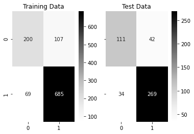

```python
f,a =  plt.subplots(1,2,sharex=True,sharey=True,squeeze=False)

#Plotting confusion matrix for the different models for the Training Data

plot_0 = sns.heatmap((metrics.confusion_matrix(Y_train,pred_class_train)),annot=True,fmt='.5g',cmap='Greys',ax=a[0][0]);
a[0][0].set_title('Training Data')

plot_1 = sns.heatmap((metrics.confusion_matrix(Y_test,pred_class_test)),annot=True,fmt='.5g',cmap='Greys',ax=a[0][1]);
a[0][1].set_title('Test Data');
```

#### Training Data and Test Data Classification Report Comparison

```python
print('Classification Report of the training data:\n\n',metrics.classification_report(Y_train,pred_class_train),'\n')
print('Classification Report of the test data:\n\n',metrics.classification_report(Y_test,pred_class_test),'\n')
```

```
Classification Report of the training data:

               precision    recall  f1-score   support

           0       0.74      0.65      0.69       307
           1       0.86      0.91      0.89       754

    accuracy                           0.83      1061
   macro avg       0.80      0.78      0.79      1061
weighted avg       0.83      0.83      0.83      1061


Classification Report of the test data:

               precision    recall  f1-score   support

           0       0.77      0.73      0.74       153
           1       0.86      0.89      0.88       303

    accuracy                           0.83       456
   macro avg       0.82      0.81      0.81       456
weighted avg       0.83      0.83      0.83       456
```

#### Probability prediction for the training and test data

```python
# Training Data Probability Prediction
pred_prob_train = modellda.predict_proba(X_train)

# Test Data Probability Prediction
pred_prob_test = modellda.predict_proba(X_test)
```

```python
pred_prob_train
```

```
array([[0.94921647, 0.05078353],
       [0.07824062, 0.92175938],
       [0.30738873, 0.69261127],
       ...,
       [0.22088844, 0.77911156],
       [0.20838927, 0.79161073],
       [0.01886825, 0.98113175]])
```

```python
pred_prob_test
```

[output not shown]

[output cut: 401 more lines]

```
       [0.35103968, 0.64896032],
       [0.93663495, 0.06336505],
       [0.10447933, 0.89552067],
       [0.67588832, 0.32411168],
       [0.00819022, 0.99180978],
       [0.84925632, 0.15074368],
       [0.01231855, 0.98768145],
       [0.6699317 , 0.3300683 ],
       [0.19879829, 0.80120171],
       [0.01896592, 0.98103408],
       [0.03070191, 0.96929809],
       [0.60844552, 0.39155448],
       [0.02845345, 0.97154655],
       [0.04671918, 0.95328082],
       [0.03135205, 0.96864795]])
```

### AUC and ROC for the training and test data

```
AUC for the Training Data: 0.889
AUC for the Test Data: 0.888
```

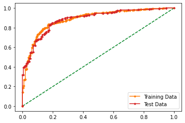

```python
# AUC and ROC for the training data

# calculate AUC
lda_train_auc = metrics.roc_auc_score(Y_train,pred_prob_train[:,1])
print('AUC for the Training Data: %.3f' % lda_train_auc)

#  calculate roc curve
fpr, tpr, thresholds = metrics.roc_curve(Y_train,pred_prob_train[:,1])
plt.plot([0, 1], [0, 1], linestyle='--')
# plot the roc curve for the model
plt.plot(fpr, tpr, marker='.',label = 'Training Data')


# AUC and ROC for the test data

# calculate AUC
lda_test_auc = metrics.roc_auc_score(Y_test,pred_prob_test[:,1])
print('AUC for the Test Data: %.3f' % lda_test_auc)

#  calculate roc curve
fpr, tpr, thresholds = metrics.roc_curve(Y_test,pred_prob_test[:,1])
plt.plot([0, 1], [0, 1], linestyle='--')
# plot the roc curve for the model
plt.plot(fpr, tpr, marker='.',label='Test Data')
# show the plot
plt.legend(loc='best')
plt.show()
```

```python
lda_metrics=classification_report(Y_train, pred_class_train,output_dict=True)
df4=pd.DataFrame(lda_metrics).transpose()
lda_train_f1=round(df4.loc["1"][2],2)
lda_train_recall=round(df4.loc["1"][1],2)
lda_train_precision=round(df4.loc["1"][0],2)
print ('lda_train_precision ',lda_train_precision)
print ('lda_train_recall ',lda_train_recall)
print ('lda_train_f1 ',lda_train_f1)
```

```
lda_train_precision  0.86
lda_train_recall  0.91
lda_train_f1  0.89
```

```python
lda_metrics=classification_report(Y_test, pred_class_test,output_dict=True)
df4=pd.DataFrame(lda_metrics).transpose()
lda_test_f1=round(df4.loc["1"][2],2)
lda_test_recall=round(df4.loc["1"][1],2)
lda_test_precision=round(df4.loc["1"][0],2)
print ('lda_test_precision ',lda_test_precision)
print ('lda_test_recall ',lda_test_recall)
print ('lda_test_f1 ',lda_test_f1)
```

```
lda_test_precision  0.86
lda_test_recall  0.89
lda_test_f1  0.88
```

```python
index=['Accuracy', 'AUC', 'Recall','Precision','F1 Score']
dataf = pd.DataFrame({'LR Train':[lr_train_acc,lr_train_auc,lr_train_recall,lr_train_precision,lr_train_f1],
        'LR Test':[lr_test_acc,lr_test_auc,lr_test_recall,lr_test_precision,lr_test_f1],
       'LDA Train':[lda_train_acc,lda_train_auc,lda_train_recall,lda_train_precision,lda_train_f1],
        'LDA Test':[lda_test_acc,lda_test_auc,lda_test_recall,lda_test_precision,lda_test_f1],},index=index)
round(dataf,2)
```

|  | LR Train | LR Test | LDA Train | LDA Test |
| --- | --- | --- | --- | --- |
| Accuracy | 0.83 | 0.83 | 0.83 | 0.83 |
| AUC | 0.89 | 0.88 | 0.89 | 0.89 |
| Recall | 0.91 | 0.88 | 0.91 | 0.89 |
| Precision | 0.86 | 0.86 | 0.86 | 0.86 |
| F1 Score | 0.89 | 0.87 | 0.89 | 0.88 |

As per train and test data accuracy, both model are best fit model.

## 1.5 Apply KNN Model and Naïve Bayes Model. Interpret the results.

### KNN Model

#### Generally, good KNN performance usually requires preprocessing of data to make all variables similarly scaled and centered. So, we can apply zscore on continues columns and see the performance for KNN.

```python
# Arrange data into independent variables and dependent variables
xknn = df.drop('vote_Labour', axis=1)
yknn = df[['vote_Labour']]
```

```python
xknn[["age","economic_cond_national","economic_cond_household","Blair","Hague","Europe","political_knowledge","gender_male"]]=xknn[["age","economic_cond_national","economic_cond_household","Blair","Hague","Europe","political_knowledge","gender_male"]].apply(zscore)
```

```python
xknn.head(10)
```

|  | age | economic_cond_national | economic_cond_household | Blair | Hague | Europe | political_knowledge | gender_male |
| --- | --- | --- | --- | --- | --- | --- | --- | --- |
| 0 | -0.716161 | -0.278185 | -0.148020 | 0.565802 | -1.419969 | -1.437338 | 0.423832 | -0.936736 |
| 1 | -1.162118 | 0.856242 | 0.926367 | 0.565802 | 1.014951 | -0.527684 | 0.423832 | 1.067536 |
| 2 | -1.225827 | 0.856242 | 0.926367 | 1.417312 | -0.608329 | -1.134120 | 0.423832 | 1.067536 |
| 3 | -1.926617 | 0.856242 | -1.222408 | -1.137217 | -1.419969 | -0.830902 | -1.421084 | -0.936736 |
| 4 | -0.843577 | -1.412613 | -1.222408 | -1.988727 | -1.419969 | -0.224465 | 0.423832 | 1.067536 |
| 5 | -0.461328 | -0.278185 | 0.926367 | 0.565802 | 1.014951 | -0.830902 | 0.423832 | 1.067536 |
| 6 | 0.175754 | -1.412613 | -1.222408 | 0.565802 | 1.014951 | 1.291625 | 0.423832 | 1.067536 |
| 7 | 1.449918 | -0.278185 | 0.926367 | 0.565802 | -1.419969 | -1.740556 | -1.421084 | 1.067536 |
| 8 | -0.970994 | -0.278185 | -0.148020 | 0.565802 | 1.014951 | 1.291625 | -1.421084 | -0.936736 |
| 9 | 1.003961 | -0.278185 | -1.222408 | 1.417312 | -1.419969 | 1.291625 | 0.423832 | 1.067536 |

```python
# Split xknn and yknn into training and test set in 70:30 ratio
from sklearn.model_selection import train_test_split
xknn_train, xknn_test, yknn_train, yknn_test = train_test_split(xknn, yknn, test_size=0.30 , random_state=10)
```

```python
from sklearn.neighbors import KNeighborsClassifier

KNN_model=KNeighborsClassifier()
modelknn=KNN_model.fit(xknn_train,yknn_train)
```

```python
## Performance Matrix on train data set
yknn_train_predict = KNN_model.predict(xknn_train)
modelk_score = KNN_model.score(xknn_train, yknn_train)
print(modelk_score)
print(metrics.confusion_matrix(yknn_train, yknn_train_predict))
print(metrics.classification_report(yknn_train, yknn_train_predict))
```

```
0.8699340245051838
[[239  82]
 [ 56 684]]
              precision    recall  f1-score   support

           0       0.81      0.74      0.78       321
           1       0.89      0.92      0.91       740

    accuracy                           0.87      1061
   macro avg       0.85      0.83      0.84      1061
weighted avg       0.87      0.87      0.87      1061
```

```python
## Performance Matrix on test data set
yknn_test_predict = KNN_model.predict(xknn_test)
modelk_score = KNN_model.score(xknn_test, yknn_test)
print(modelk_score)
print(metrics.confusion_matrix(yknn_test, yknn_test_predict))
print(metrics.classification_report(yknn_test, yknn_test_predict))
```

```
0.8245614035087719
[[ 95  44]
 [ 36 281]]
              precision    recall  f1-score   support

           0       0.73      0.68      0.70       139
           1       0.86      0.89      0.88       317

    accuracy                           0.82       456
   macro avg       0.79      0.78      0.79       456
weighted avg       0.82      0.82      0.82       456
```

Default value n_neighbors=5, lets check the performance for the KNN with no of neighbours to be 1,3,5..19 and *Find the optimal number of neighbours from K=1,3,5,7....19 using the Mis classification error

```python
# empty list that will hold accuracy scores
ac_scores = []

# perform accuracy metrics for values from 1,3,5....19
for k in range(1,20,2):
    knn = KNeighborsClassifier(n_neighbors=k)
    knn.fit(xknn_train, yknn_train)
    # evaluate test accuracy
    scores = knn.score(xknn_test, yknn_test)
    ac_scores.append(scores)

# changing to misclassification error
MCE = [1 - x for x in ac_scores]
MCE
```

```
[0.23026315789473684,
 0.18201754385964908,
 0.17543859649122806,
 0.1907894736842105,
 0.19298245614035092,
 0.19298245614035092,
 0.1864035087719298,
 0.1907894736842105,
 0.1885964912280702,
 0.1842105263157895]
```

#### Plot misclassification error vs k (with k value on X-axis)

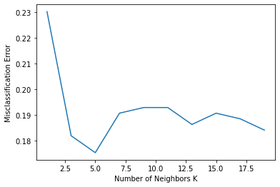

```python
import matplotlib.pyplot as plt
# plot misclassification error vs k
plt.plot(range(1,20,2), MCE)
plt.xlabel('Number of Neighbors K')
plt.ylabel('Misclassification Error')
plt.show()
```

Compared with other K values, K = 5 is giving the low MCE value. Lets check train and test for K=5 with other evaluation metrics

```python
from sklearn.neighbors import KNeighborsClassifier

KNN_model=KNeighborsClassifier(n_neighbors=5)
KNN_model.fit(xknn_train,yknn_train)
```

```
KNeighborsClassifier()
```

```python
## Performance Matrix on train data set
yknn_train_predict = KNN_model.predict(xknn_train)
modelk_score = KNN_model.score(xknn_train, yknn_train)
print(modelk_score)
print(metrics.confusion_matrix(yknn_train, yknn_train_predict))
print(metrics.classification_report(yknn_train, yknn_train_predict))
```

```
0.8699340245051838
[[239  82]
 [ 56 684]]
              precision    recall  f1-score   support

           0       0.81      0.74      0.78       321
           1       0.89      0.92      0.91       740

    accuracy                           0.87      1061
   macro avg       0.85      0.83      0.84      1061
weighted avg       0.87      0.87      0.87      1061
```

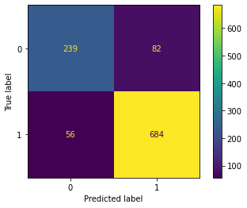

```python
plot_confusion_matrix(KNN_model,xknn_train,yknn_train);
```

```python
## Performance Matrix on test data set
yknn_test_predict = KNN_model.predict(xknn_test)
modelk_score = KNN_model.score(xknn_test, yknn_test)
print(modelk_score)
print(metrics.confusion_matrix(yknn_test, yknn_test_predict))
print(metrics.classification_report(yknn_test, yknn_test_predict))
```

```
0.8245614035087719
[[ 95  44]
 [ 36 281]]
              precision    recall  f1-score   support

           0       0.73      0.68      0.70       139
           1       0.86      0.89      0.88       317

    accuracy                           0.82       456
   macro avg       0.79      0.78      0.79       456
weighted avg       0.82      0.82      0.82       456
```

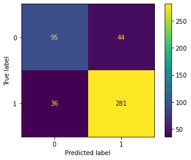

```python
plot_confusion_matrix(KNN_model,xknn_test,yknn_test);
```

```python
0.8699340245051838 - 0.8245614035087719
```

```
0.04537262099641182
```

#### As the difference between train and test accuracies is 4.5%, that is less than 10%. So, it is a valid model for K=5.

#### Probability prediction for the training and test data

```python
# Training Data Probability Prediction
pred_prob_train = KNN_model.predict_proba(xknn_train)

# Test Data Probability Prediction
pred_prob_test = KNN_model.predict_proba(xknn_test)
```

```
AUC for the Training Data: 0.936
AUC for the Test Data: 0.841
```

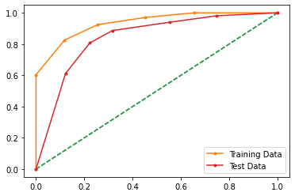

```python
# AUC and ROC for the training data

# calculate AUC
knn_train_auc = metrics.roc_auc_score(yknn_train,pred_prob_train[:,1])
print('AUC for the Training Data: %.3f' % knn_train_auc)

#  calculate roc curve
fpr, tpr, thresholds = metrics.roc_curve(yknn_train,pred_prob_train[:,1])
plt.plot([0, 1], [0, 1], linestyle='--')
# plot the roc curve for the model
plt.plot(fpr, tpr, marker='.',label = 'Training Data')


# AUC and ROC for the test data

# calculate AUC
knn_test_auc = metrics.roc_auc_score(yknn_test,pred_prob_test[:,1])
print('AUC for the Test Data: %.3f' % knn_test_auc)

#  calculate roc curve
fpr, tpr, thresholds = metrics.roc_curve(yknn_test,pred_prob_test[:,1])
plt.plot([0, 1], [0, 1], linestyle='--')
# plot the roc curve for the model
plt.plot(fpr, tpr, marker='.',label='Test Data')
# show the plot
plt.legend(loc='best')
plt.show()
```

### Gaussian Naive Bayes

```python
from sklearn.naive_bayes import GaussianNB
from sklearn import metrics
```

```python
NB_model = GaussianNB()
NB_model.fit(x_train, y_train)
```

```
GaussianNB()
```

Now GaussianNB classifier is built. The classifier is trained using training data. We can use fit() method for training it. After building a classifier, our model is ready to make predictions. We can use predict() method with test set features as its parameters.

#### Performance Matrix on train data set

```python
y_train_predict = NB_model.predict(x_train)
model_score = NB_model.score(x_train, y_train)                      ## Accuracy
print(model_score)
print(metrics.confusion_matrix(y_train, y_train_predict))          ## confusion_matrix
print(metrics.classification_report(y_train, y_train_predict))     ## classification_report
```

```
0.8350612629594723
[[211  96]
 [ 79 675]]
              precision    recall  f1-score   support

           0       0.73      0.69      0.71       307
           1       0.88      0.90      0.89       754

    accuracy                           0.84      1061
   macro avg       0.80      0.79      0.80      1061
weighted avg       0.83      0.84      0.83      1061
```

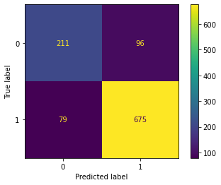

```python
plot_confusion_matrix(NB_model,x_train,y_train);
```

#### Performance Matrix on test data set

```python
y_test_predict = NB_model.predict(x_test)
model_score = NB_model.score(x_test, y_test)                    ## Accuracy
print(model_score)
print(metrics.confusion_matrix(y_test, y_test_predict))         ## confusion_matrix
print(metrics.classification_report(y_test, y_test_predict))    ## classification_report
```

```
0.8223684210526315
[[112  41]
 [ 40 263]]
              precision    recall  f1-score   support

           0       0.74      0.73      0.73       153
           1       0.87      0.87      0.87       303

    accuracy                           0.82       456
   macro avg       0.80      0.80      0.80       456
weighted avg       0.82      0.82      0.82       456
```

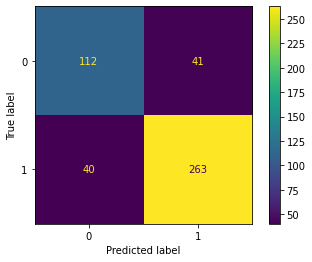

```python
plot_confusion_matrix(NB_model,x_test,y_test);
```

#### Accuracy of our Gaussian Naive Bayes model

```python
NB_model.score(x_train, y_train)
```

```
0.8350612629594723
```

```python
NB_model.score(x_test, y_test)
```

```
0.8223684210526315
```

#### Probability prediction for the training and test data

```python
# Training Data Probability Prediction
pred_prob_train = NB_model.predict_proba(x_train)

# Test Data Probability Prediction
pred_prob_test = NB_model.predict_proba(x_test)
```

```
AUC for the Training Data: 0.888
AUC for the Test Data: 0.876
```

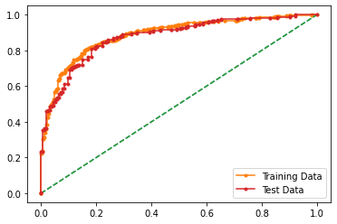

```python
# AUC and ROC for the training data

# calculate AUC
NB_train_auc = metrics.roc_auc_score(y_train,pred_prob_train[:,1])
print('AUC for the Training Data: %.3f' % NB_train_auc)

#  calculate roc curve
fpr, tpr, thresholds = metrics.roc_curve(y_train,pred_prob_train[:,1])
plt.plot([0, 1], [0, 1], linestyle='--')
# plot the roc curve for the model
plt.plot(fpr, tpr, marker='.',label = 'Training Data')


# AUC and ROC for the test data

# calculate AUC
NB_test_auc = metrics.roc_auc_score(y_test,pred_prob_test[:,1])
print('AUC for the Test Data: %.3f' % NB_test_auc)

#  calculate roc curve
fpr, tpr, thresholds = metrics.roc_curve(y_test,pred_prob_test[:,1])
plt.plot([0, 1], [0, 1], linestyle='--')
# plot the roc curve for the model
plt.plot(fpr, tpr, marker='.',label='Test Data')
# show the plot
plt.legend(loc='best')
plt.show()
```

#### As per the Training accuracy and Test accuracy, Model seems to be performing well.

## 1.6 Model Tuning, Bagging (Random Forest should be applied for Bagging), and Boosting.

#### Model tuning - We can use Grid SearchCV to tune all bagging models. For KNN we have used model tuning to find best K value.

```python
from sklearn.model_selection import GridSearchCV
```

### To implement Bagging

### Decision Tree

```python
from sklearn import tree
from sklearn.tree import DecisionTreeClassifier
from sklearn.ensemble import RandomForestClassifier
param_grid = {
    'criterion': ['gini'],
    'max_depth': [5,10,20,30],
    'min_samples_leaf': [2,5,10,20],
    'min_samples_split': [10,20,50,100,150,200],
}

dtcl = DecisionTreeClassifier(random_state=1)

grid_search = GridSearchCV(estimator = dtcl, param_grid = param_grid, cv = 10)
```

```python
grid_search.fit(x_train, y_train)
print(grid_search.best_params_)
best_grid1 = grid_search.best_estimator_
best_grid1
```

```
{'criterion': 'gini', 'max_depth': 5, 'min_samples_leaf': 5, 'min_samples_split': 10}
```

```
DecisionTreeClassifier(max_depth=5, min_samples_leaf=5, min_samples_split=10,
                       random_state=1)
```

#### Generating Tree

```python
train_char_label = ['no', 'yes']
tree_regularized = open('tree_regularized.dot','w')
dot_data = tree.export_graphviz(best_grid1, out_file= tree_regularized , feature_names = list(x_train), class_names = list(train_char_label))

tree_regularized.close()
dot_data
```

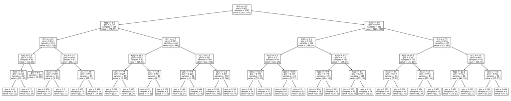

```python
plt.figure(figsize=(50,10))
tree.plot_tree(best_grid1, fontsize=10)
plt.show()
```

```python
## Performance Matrix on train data set
y_train_predict = best_grid1.predict(x_train)
model_score = best_grid1.score(x_train, y_train)
print(model_score)
print(metrics.confusion_matrix(y_train, y_train_predict))
print(metrics.classification_report(y_train, y_train_predict))
```

```
0.8557964184731386
[[225  82]
 [ 71 683]]
              precision    recall  f1-score   support

           0       0.76      0.73      0.75       307
           1       0.89      0.91      0.90       754

    accuracy                           0.86      1061
   macro avg       0.83      0.82      0.82      1061
weighted avg       0.85      0.86      0.86      1061
```

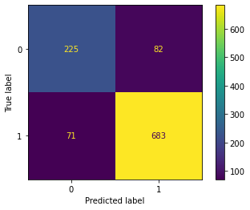

```python
plot_confusion_matrix(best_grid1,x_train,y_train);
```

```python
## Performance Matrix on test data set
y_test_predict = best_grid1.predict(x_test)
model_score = best_grid1.score(x_test, y_test)
print(model_score)
print(metrics.confusion_matrix(y_test, y_test_predict))
print(metrics.classification_report(y_test, y_test_predict))
```

```
0.8092105263157895
[[106  47]
 [ 40 263]]
              precision    recall  f1-score   support

           0       0.73      0.69      0.71       153
           1       0.85      0.87      0.86       303

    accuracy                           0.81       456
   macro avg       0.79      0.78      0.78       456
weighted avg       0.81      0.81      0.81       456
```

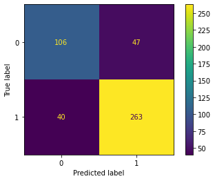

```python
plot_confusion_matrix(best_grid1,x_test,y_test);
```

#### Probability prediction for the training and test data

```python
# Training Data Probability Prediction
pred_prob_train = best_grid1.predict_proba(x_train)

# Test Data Probability Prediction
pred_prob_test = best_grid1.predict_proba(x_test)
```

```
AUC for the Training Data: 0.915
AUC for the Test Data: 0.847
```

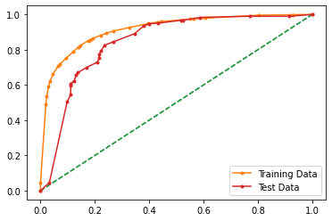

```python
# AUC and ROC for the training data

# calculate AUC
DT_train_auc = metrics.roc_auc_score(y_train,pred_prob_train[:,1])
print('AUC for the Training Data: %.3f' % DT_train_auc)

#  calculate roc curve
fpr, tpr, thresholds = metrics.roc_curve(y_train,pred_prob_train[:,1])
plt.plot([0, 1], [0, 1], linestyle='--')
# plot the roc curve for the model
plt.plot(fpr, tpr, marker='.',label = 'Training Data')


# AUC and ROC for the test data

# calculate AUC
DT_test_auc = metrics.roc_auc_score(y_test,pred_prob_test[:,1])
print('AUC for the Test Data: %.3f' % DT_test_auc)

#  calculate roc curve
fpr, tpr, thresholds = metrics.roc_curve(y_test,pred_prob_test[:,1])
plt.plot([0, 1], [0, 1], linestyle='--')
# plot the roc curve for the model
plt.plot(fpr, tpr, marker='.',label='Test Data')
# show the plot
plt.legend(loc='best')
plt.show()
```

#### Feature Importances

```python
best_dt= grid_search.best_estimator_
```

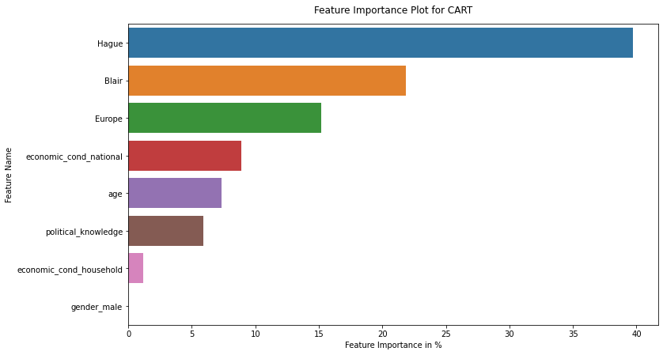

```python
x=pd.DataFrame(best_dt.feature_importances_*100,index=x_train.columns).sort_values(by=0,ascending=False)
plt.figure(figsize=(12,7))
sns.barplot(x[0],x.index)
plt.ylabel('Feature Name')
plt.xlabel('Feature Importance in %')
plt.title('Feature Importance Plot for CART',y=1.02)
plt.show()
```

#### Random Forest

```python
param_grid = {
    'max_depth': [10], #[2,5,10,20],
    'max_features': [4], #[3,4,5,6,7],
    'min_samples_leaf': [5], #[2,5,10,50],
    'min_samples_split': [20], #[5,10,20],
    'n_estimators': [50], #[50,100]
}

rfcl = RandomForestClassifier(random_state=1)

grid_search = GridSearchCV(estimator = rfcl, param_grid = param_grid, cv = 5)
```

```python
grid_search.fit(x_train, y_train)
grid_search.best_params_
best_grid2 = grid_search.best_estimator_
best_grid2
```

```
RandomForestClassifier(max_depth=10, max_features=4, min_samples_leaf=5,
                       min_samples_split=20, n_estimators=50, random_state=1)
```

```python
## Performance Matrix on train data set
y_train_predict = best_grid2.predict(x_train)
model_score = best_grid2.score(x_train, y_train)
print(model_score)
print(metrics.confusion_matrix(y_train, y_train_predict))
print(metrics.classification_report(y_train, y_train_predict))
```

```
0.8765315739868049
[[222  85]
 [ 46 708]]
              precision    recall  f1-score   support

           0       0.83      0.72      0.77       307
           1       0.89      0.94      0.92       754

    accuracy                           0.88      1061
   macro avg       0.86      0.83      0.84      1061
weighted avg       0.87      0.88      0.87      1061
```

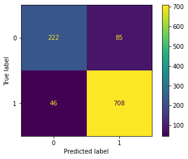

```python
plot_confusion_matrix(best_grid2,x_train,y_train);
```

```python
## Performance Matrix on test data set
y_test_predict = best_grid2.predict(x_test)
model_score = best_grid2.score(x_test, y_test)
print(model_score)
print(metrics.confusion_matrix(y_test, y_test_predict))
print(metrics.classification_report(y_test, y_test_predict))
```

```
0.8223684210526315
[[103  50]
 [ 31 272]]
              precision    recall  f1-score   support

           0       0.77      0.67      0.72       153
           1       0.84      0.90      0.87       303

    accuracy                           0.82       456
   macro avg       0.81      0.79      0.79       456
weighted avg       0.82      0.82      0.82       456
```

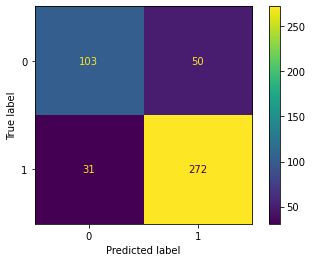

```python
plot_confusion_matrix(best_grid2,x_test,y_test);
```

#### Probability prediction for the training and test data

```python
# Training Data Probability Prediction
pred_prob_train = best_grid2.predict_proba(x_train)

# Test Data Probability Prediction
pred_prob_test = best_grid2.predict_proba(x_test)
```

```
AUC for the Training Data: 0.941
AUC for the Test Data: 0.895
```

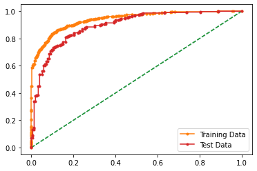

```python
# AUC and ROC for the training data

# calculate AUC
RF_train_auc = metrics.roc_auc_score(y_train,pred_prob_train[:,1])
print('AUC for the Training Data: %.3f' % RF_train_auc)

#  calculate roc curve
fpr, tpr, thresholds = metrics.roc_curve(y_train,pred_prob_train[:,1])
plt.plot([0, 1], [0, 1], linestyle='--')
# plot the roc curve for the model
plt.plot(fpr, tpr, marker='.',label = 'Training Data')


# AUC and ROC for the test data

# calculate AUC
RF_test_auc = metrics.roc_auc_score(y_test,pred_prob_test[:,1])
print('AUC for the Test Data: %.3f' % RF_test_auc)

#  calculate roc curve
fpr, tpr, thresholds = metrics.roc_curve(y_test,pred_prob_test[:,1])
plt.plot([0, 1], [0, 1], linestyle='--')
# plot the roc curve for the model
plt.plot(fpr, tpr, marker='.',label='Test Data')
# show the plot
plt.legend(loc='best')
plt.show()
```

#### Feature Importances

```python
best_rf= grid_search.best_estimator_
```

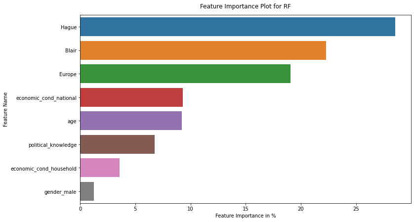

```python
x=pd.DataFrame(best_rf.feature_importances_*100,index=x_train.columns).sort_values(by=0,ascending=False)
plt.figure(figsize=(12,7))
sns.barplot(x[0],x.index)
plt.ylabel('Feature Name')
plt.xlabel('Feature Importance in %')
plt.title('Feature Importance Plot for RF',y=1.02)
plt.show()
```

### Bagging

```python
from sklearn.ensemble import BaggingClassifier
from sklearn.ensemble import RandomForestClassifier
rf = RandomForestClassifier()
Bagging_model=BaggingClassifier(base_estimator=rf,n_estimators=100,random_state=1)
Bagging_model.fit(x_train, y_train)
```

```
BaggingClassifier(base_estimator=RandomForestClassifier(), n_estimators=100,
                  random_state=1)
```

```python
## Performance Matrix on train data set
y_train_predict = Bagging_model.predict(x_train)
model_score =Bagging_model.score(x_train, y_train)
print(model_score)
print(metrics.confusion_matrix(y_train, y_train_predict))
print(metrics.classification_report(y_train, y_train_predict))
```

```
0.9679547596606974
[[277  30]
 [  4 750]]
              precision    recall  f1-score   support

           0       0.99      0.90      0.94       307
           1       0.96      0.99      0.98       754

    accuracy                           0.97      1061
   macro avg       0.97      0.95      0.96      1061
weighted avg       0.97      0.97      0.97      1061
```

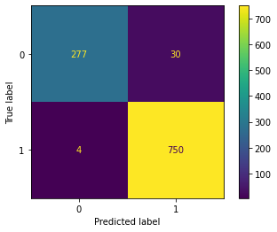

```python
plot_confusion_matrix(Bagging_model,x_train,y_train);
```

```python
## Performance Matrix on test data set
y_test_predict = Bagging_model.predict(x_test)
model_score = Bagging_model.score(x_test, y_test)
print(model_score)
print(metrics.confusion_matrix(y_test, y_test_predict))
print(metrics.classification_report(y_test, y_test_predict))
```

```
0.8289473684210527
[[104  49]
 [ 29 274]]
              precision    recall  f1-score   support

           0       0.78      0.68      0.73       153
           1       0.85      0.90      0.88       303

    accuracy                           0.83       456
   macro avg       0.82      0.79      0.80       456
weighted avg       0.83      0.83      0.83       456
```

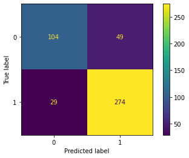

```python
plot_confusion_matrix(Bagging_model,x_test,y_test);
```

#### Probability prediction for the training and test data

```python
# Training Data Probability Prediction
pred_prob_train = Bagging_model.predict_proba(x_train)

# Test Data Probability Prediction
pred_prob_test = Bagging_model.predict_proba(x_test)
```

```
AUC for the Training Data: 0.997
AUC for the Test Data: 0.897
```

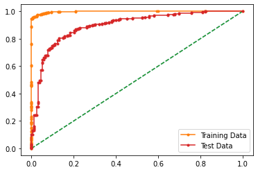

```python
# AUC and ROC for the training data

# calculate AUC
BM_train_auc = metrics.roc_auc_score(y_train,pred_prob_train[:,1])
print('AUC for the Training Data: %.3f' % BM_train_auc)

#  calculate roc curve
fpr, tpr, thresholds = metrics.roc_curve(y_train,pred_prob_train[:,1])
plt.plot([0, 1], [0, 1], linestyle='--')
# plot the roc curve for the model
plt.plot(fpr, tpr, marker='.',label = 'Training Data')


# AUC and ROC for the test data

# calculate AUC
BM_test_auc = metrics.roc_auc_score(y_test,pred_prob_test[:,1])
print('AUC for the Test Data: %.3f' % BM_test_auc)

#  calculate roc curve
fpr, tpr, thresholds = metrics.roc_curve(y_test,pred_prob_test[:,1])
plt.plot([0, 1], [0, 1], linestyle='--')
# plot the roc curve for the model
plt.plot(fpr, tpr, marker='.',label='Test Data')
# show the plot
plt.legend(loc='best')
plt.show()
```